# simfft()

Nathaniel Phillips

2016-06-20

This function simulates multiple cross-validations of data with the `fft()` function.

## Example with breastcancer

Let’s start with an example, we’ll create FFTs fitted to the `breastcancer` dataset. Here’s how the dataset looks:

```r
head(breastcancer)
```

```
##   thickness cellsize.unif cellshape.unif adhesion epithelial nuclei.bare
## 1         5             1              1        1          2           1
## 2         5             4              4        5          7          10
## 3         3             1              1        1          2           2
## 4         6             8              8        1          3           4
## 5         4             1              1        3          2           1
## 6         8            10             10        8          7          10
##   chromatin nucleoli mitoses diagnosis
## 1         3        1       1         B
## 2         3        2       1         B
## 3         3        1       1         B
## 4         3        7       1         B
## 5         3        1       1         B
## 6         9        7       1         M
```

```r
set.seed(100) # For reproducability

bcancer.fft.sim <- simfft(
  train.cue.df = breastcancer[,names(breastcancer) != "diagnosis"],
  train.criterion.v =  breastcancer$diagnosis == "M",
  train.p = .1,
  sim.n = 10
)
```

## Results

The function will return a dataframe with fitting and test results for each simulation:

```r
bcancer.fft.sim
```

```
##    train.p sim fft.hr.train fft.far.train fft.hr.test fft.far.test
## 1      0.1   1    0.9523810    0.04255319   0.9220183   0.04534005
## 2      0.1   2    0.9545455    0.04347826   0.7926267   0.02261307
## 3      0.1   3    1.0000000    0.05000000   0.9573460   0.10396040
## 4      0.1   4    0.9523810    0.04255319   0.9587156   0.06045340
## 5      0.1   5    1.0000000    0.02040816   0.8636364   0.05063291
## 6      0.1   6    1.0000000    0.04444444   0.9722222   0.08020050
## 7      0.1   7    1.0000000    0.00000000   0.6711712   0.01526718
## 8      0.1   8    1.0000000    0.06976744   0.9953271   0.18703242
## 9      0.1   9    1.0000000    0.04255319   0.9954128   0.16372796
## 10     0.1  10    0.9583333    0.06818182   0.9395349   0.06250000
##    fft.level.class               fft.level.name fft.level.exit
## 1  integer;integer cellsize.unif;cellshape.unif          1;0.5
## 2  integer;integer    cellshape.unif;epithelial          0;0.5
## 3  integer;integer cellsize.unif;cellshape.unif          1;0.5
```

[output cut: 40 more lines]

## Plotting the results

You can plot the results using the `simfftplot()` function.

### Which cues were selected the most often?

If you set `roc = F` you’ll see a bar chart showing how often each of the possible cues was used in trees. This gives you an indication of how important each cue is. For example, if a cue is used in >95% of simulations, this suggests that the cue is a consistently good predictor of the criterion across a wide range of training samples.

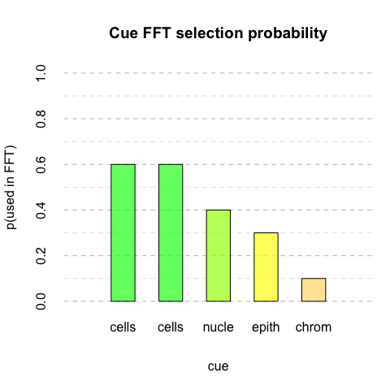

```r
simfftplot(bcancer.fft.sim,
           roc = F
           )
```

### How well (and consistently) did the trees perform?

If you set `roc = T`, you’ll see a distribution of hit-rates and false-alarm rates for trees across all simulations. You can also specify which data (training or test) to display with `which.data`.

Here, we can see the distribution of HR and FAR for the training data:

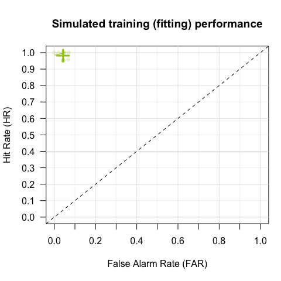

```r
simfftplot(bcancer.fft.sim,
           roc = T,
           which.data = "train"
           )
```

Now let’s do the testing data. We should expect the trees to do a bit worse here:

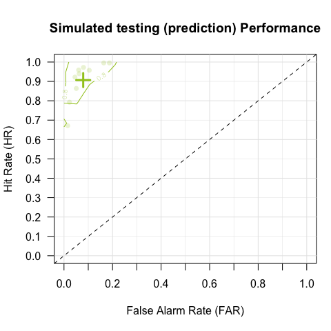

```r
simfftplot(bcancer.fft.sim,
           roc = T,
           which.data = "test"
           )
```

To add curves for CART and Logistic Regression by including the arguments `lr = T` and `cart = T`. Let’s look at the performance of CART and LR compared to the trees for the training data:

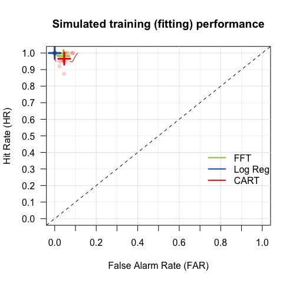

```r
simfftplot(bcancer.fft.sim,
           roc = T,
           lr = T,
           cart = T,
           which.data = "train"
           )
```

It looks like LR dominated both CART and FFTs for the training data (in fact, for this simulation, LR always gave a perfect fit). Now let’s look at the test data:

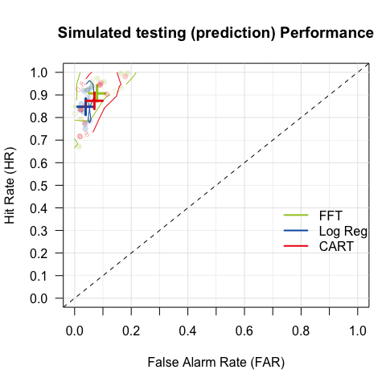

```r
simfftplot(bcancer.fft.sim,
           roc = T,
           lr = T,
           cart = T,
           which.data = "test"
           )
```

Here, we can see that for the testing data, all three algorithms performed similarly well.